# Environmental Resource Consumption and Service Demand in Melbourne

## **Conclusion**

This analysis highlights the interplay between operational activities and environmental impact, underscoring the need for sustainable resource management. Strategic interventions can optimize resource allocation while maintaining service quality and reducing environmental footprints.

```
Merged Data (Requests vs Resource Consumption):
  year_month  total_requests    year  month   amount  \
0 2011-05-01             0.0  2011.0    5.0    0.000
1 2012-03-01             0.0  2012.0    3.0  628.136
2 2012-08-01             0.0  2012.0    8.0    0.000
3 2012-11-01             0.0  2012.0   11.0   25.000
4 2013-02-01             0.0  2013.0    2.0    0.000

   total_greenhouse_gases_(t_co2-e)
0                          0.000000
1                        842.402303
2                          0.000000
3                         49.346154
4                          0.000000
Shape of Merged Data: (46, 6)
Summary of Resource Amounts in Merged Data:
count    4.600000e+01
mean     1.470755e+06
std      3.376414e+06
min      0.000000e+00
25%      0.000000e+00
50%      0.000000e+00
75%      3.041318e+06
max      2.067448e+07
Name: amount, dtype: float64
Summary of Greenhouse Gases in Merged Data:
count    4.600000e+01
mean     9.806926e+05
std      1.912711e+06
min      0.000000e+00
25%      0.000000e+00
50%      0.000000e+00
75%      2.322850e+06
max      1.029891e+07
Name: total_greenhouse_gases_(t_co2-e), dtype: float64
Correlation Matrix between Requests and Resource Consumption:
                                  total_requests    amount  \
total_requests                          1.000000 -0.438503
amount                                 -0.438503  1.000000
total_greenhouse_gases_(t_co2-e)       -0.516145  0.961808

                                  total_greenhouse_gases_(t_co2-e)
total_requests                                           -0.516145
amount                                                    0.961808
total_greenhouse_gases_(t_co2-e)                          1.000000
```

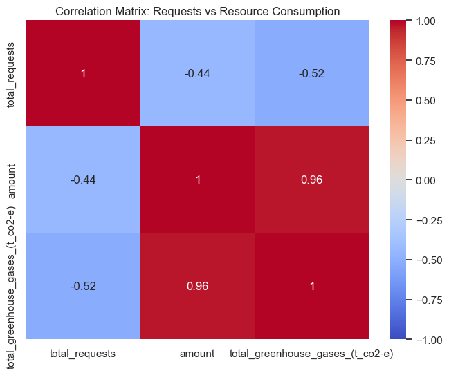

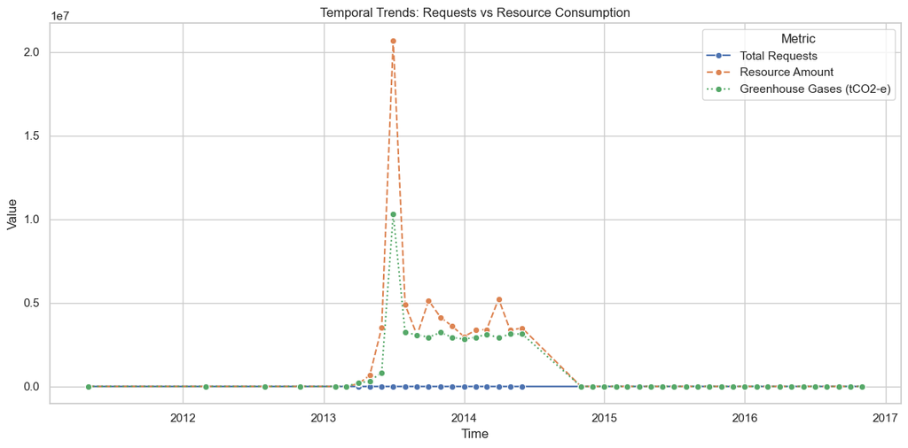

```python
# Group total requests by year_month for all suburbs and categories
temporal_requests = filtered_temporal_df.groupby(['year_month']).size().reset_index(name='total_requests')

# Convert 'year_month' in temporal_requests to datetime format
temporal_requests['year_month'] = temporal_requests['year_month'].dt.to_timestamp()

# Group resource consumption by year_month
resource_consumption = monthly_env_consumption.groupby(['year', 'month'])[['amount', 'total_greenhouse_gases_(t_co2-e)']].sum().reset_index()

# Convert year and month to datetime in resource consumption for merging
resource_consumption['year_month'] = pd.to_datetime(resource_consumption['year'].astype(str) + '-' + resource_consumption['month'].astype(str) + '-01')

# Merge requests with resource consumption on year_month using outer join
merged_trends_resources = pd.merge(temporal_requests, resource_consumption, on='year_month', how='outer')

# Fill missing values with 0 for analysis
merged_trends_resources.fillna(0, inplace=True)

# Debugging Outputs
print("Merged Data (Requests vs Resource Consumption):")
print(merged_trends_resources.head())
print("Shape of Merged Data:", merged_trends_resources.shape)

# Check for missing or zero data
print("Summary of Resource Amounts in Merged Data:")
print(merged_trends_resources['amount'].describe())

print("Summary of Greenhouse Gases in Merged Data:")
print(merged_trends_resources['total_greenhouse_gases_(t_co2-e)'].describe())

# Calculate correlation matrix between requests, amount, and greenhouse gases
correlation_matrix = merged_trends_resources[['total_requests', 'amount', 'total_greenhouse_gases_(t_co2-e)']].corr()

# Print the correlation matrix
print("Correlation Matrix between Requests and Resource Consumption:")
print(correlation_matrix)

# Plot the correlation matrix
plt.figure(figsize=(8, 6))
sns.heatmap(correlation_matrix, annot=True, cmap='coolwarm', vmin=-1, vmax=1)
plt.title('Correlation Matrix: Requests vs Resource Consumption')
plt.show()

# Plot temporal trends for requests and resource consumption
plt.figure(figsize=(12, 6))
sns.lineplot(data=merged_trends_resources, x='year_month', y='total_requests', label='Total Requests', marker='o')
sns.lineplot(data=merged_trends_resources, x='year_month', y='amount', label='Resource Amount', marker='o', linestyle='--')
sns.lineplot(data=merged_trends_resources, x='year_month', y='total_greenhouse_gases_(t_co2-e)', label='Greenhouse Gases (tCO2-e)', marker='o', linestyle=':')
plt.title('Temporal Trends: Requests vs Resource Consumption')
plt.xlabel('Time')
plt.ylabel('Value')
plt.legend(title='Metric')
plt.grid(True)
plt.tight_layout()
plt.show()
```

# **Seasonal Trends in Resource Usage and Emissions**

## **Objective**

To analyze seasonal patterns in resource usage and emissions across the year, identifying months with peak activities and their environmental impact.

## **Methodology**

1. **Data Preparation**:
   - Extracted the **month** from the `year_month` column in the merged dataset containing both service request and resource consumption data.
   - Grouped the data by **month** to calculate **average resource usage** and **average emissions** across all years.
2. **Analysis**:
   - Computed monthly averages for:
     - **Resource Amount**: Quantifying the volume of resources consumed.
     - **Emissions (tCO2-e)**: Measuring greenhouse gas emissions resulting from resource usage.
   - Visualized trends using a line plot to identify peaks and seasonal fluctuations.

## **Visualizations**

### **1. Seasonal Trends**

- A line plot illustrates monthly averages for both **resource usage** and **emissions**:
  - **Sharp Peak in July**: Highlights the need for focused resource efficiency strategies during this period.
  - **Similar Trends**: Resource usage and emissions closely align across all months, confirming the direct relationship between the two.

## **Conclusion**

This seasonal analysis reveals clear trends in resource usage and environmental impact, with significant implications for operational planning and sustainability. Addressing mid-year peaks can improve efficiency and reduce environmental costs while maintaining service quality.

```
Seasonal Analysis - Average Resource Usage and Emissions by Month:
    month  avg_resource_amount  avg_emissions
0       1         9.934747e+05   9.400519e+05
1       2         8.412421e+05   7.355901e+05
2       3         6.807505e+05   6.239101e+05
3       4         1.345577e+06   7.788187e+05
4       5         8.066474e+05   6.890033e+05
5       6         1.751024e+06   9.915318e+05
6       7         6.891495e+06   3.432969e+06
7       8         1.219898e+06   8.051418e+05
8       9         1.020538e+06   1.027201e+06
9      10         1.710061e+06   9.801467e+05
10     11         8.269001e+05   6.450548e+05
11     12         1.201861e+06   9.788621e+05
```

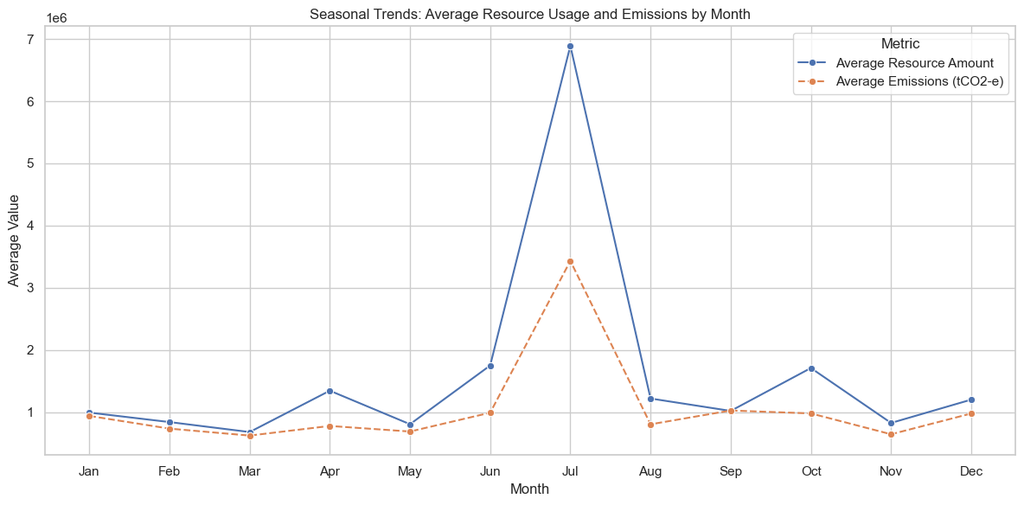

```python
# Extract month from the 'year_month' column for seasonal analysis
merged_trends_resources['month'] = merged_trends_resources['year_month'].dt.month

# Group by month to calculate average resource usage and emissions
seasonal_analysis = merged_trends_resources.groupby('month')[['amount', 'total_greenhouse_gases_(t_co2-e)']].mean().reset_index()

# Rename columns for better readability
seasonal_analysis.rename(columns={'amount': 'avg_resource_amount', 'total_greenhouse_gases_(t_co2-e)': 'avg_emissions'}, inplace=True)

# Debugging Output
print("Seasonal Analysis - Average Resource Usage and Emissions by Month:")
print(seasonal_analysis)

# Plot average resource usage and emissions by month
plt.figure(figsize=(12, 6))
sns.lineplot(data=seasonal_analysis, x='month', y='avg_resource_amount', label='Average Resource Amount', marker='o')
sns.lineplot(data=seasonal_analysis, x='month', y='avg_emissions', label='Average Emissions (tCO2-e)', marker='o', linestyle='--')
plt.title('Seasonal Trends: Average Resource Usage and Emissions by Month')
plt.xlabel('Month')
plt.ylabel('Average Value')
plt.xticks(ticks=range(1, 13), labels=['Jan', 'Feb', 'Mar', 'Apr', 'May', 'Jun', 'Jul', 'Aug', 'Sep', 'Oct', 'Nov', 'Dec'])
plt.legend(title='Metric')
plt.grid(True)
plt.tight_layout()
plt.show()
```